# Intro to R, loops, and functions

Advanced Ecology: Populations and Communities

9/28/2021

## Getting to know the basics

R is a programming language that has become the standard in Ecology due to its flexibility and open source nature. R can be used from simple math to complex models and is very useful for generating figures. R, like all computer languages, using a specific syntax to run commands that it is programmed to do. In other words, R will only do what it is commanded to do, and therefore, many common errors are due to errors in syntax (e.g. misspellings, missed commas, or unclosed brackets).

This example gives a basic intro into R syntax that can be useful for ecological modeling. This script gives examples of how to:

1. Basic operations in R
2. Assigning objects
3. Types of data structures in R
4. Functions in R
5. Using Packages in R
- How to install and load packages
- tidyverse
  - tidy data
  - piping
6. Indexing
7. Vector operations
- Custom Functions
- `plyr` and `dplyr`
- `purr`
8. For loops
- Plotting
9. Homework

## Basic operations in R

R is useful for basic operations and follows math rules (i.e. PEMDAS). R will all code on a line unless there is a `#` to the left.

```r
# addition
1+1
```

```
## [1] 2
```

```r
1+1 # + 2 (won't run anything to right of #)
```

```
## [1] 2
```

```r
# subtraction
5-2
```

```
## [1] 3
```

```r
# multiplication
4*5
```

```
## [1] 20
```

```r
# division
33/5
```

```
## [1] 6.6
```

```r
# exponents can be done 2 ways
2^2
```

```
## [1] 4
```

```r
2**2
```

```
## [1] 4
```

```r
# follows PEMDAS
1+5*4
```

```
## [1] 21
```

```r
# different answer than above
(1+5)*4
```

```
## [1] 24
```

Note the `[1]` appears next to your result. R is just letting you know that this line begins with the first value in your result. Some commands return more than one value, and their results may fill up multiple lines. For example, the command 100:130 returns 31 values; it creates a sequence of integers from 100 to 130. Notice that new bracketed numbers appear at the start of the first and second lines of output. These numbers just mean that the second line begins with that value. You can mostly ignore the numbers that appear in brackets:

```r
100:130
```

```
##  [1] 100 101 102 103 104 105 106 107 108 109 110 111 112 113 114 115 116 117 118
## [20] 119 120 121 122 123 124 125 126 127 128 129 130
```

## Assigning objects

When working in R it is useful to store data as an object. Assigning objects can be done in multiple ways, but the most common are `<-` and `=`. These objects are stored in the R environment and can be called. Objects can be assigned multiple times, but only the last assignment is what is stored. Also it is important to know that R is case sensative and capital and lower case numbers are different.

```r
# assign an object
a = 4
a
```

```
## [1] 4
```

```r
b <- 23

a+3
```

```
## [1] 7
```

```r
b/2
```

```
## [1] 11.5
```

```r
a*b
```

```
## [1] 92
```

```r
c = 8
c = 14
c
```

```
## [1] 14
```

```r
d = 15
D = 1
d
```

```
## [1] 15
```

```r
D
```

```
## [1] 1
```

## Types of data structures in R

R has 6 basic data types. (In addition to the five listed below, there is also raw which will not be discussed in this workshop.)

- integer
- numeric (real or decimal)
- character
- logical
- complex

integers are whole numbers

numeric are numbers with decimals. Integers and numeric are different because of how the underlying data is stored.

characters are strings of letters and numbers (e.g. `"abc"` and `"b1x"`) and are designated in R by `" "`. When using characters, `" "` are required because in R letters without quotations are objects and `c = 'd'` is different than `c = d`

logical is `TRUE` or `FALSE`. One thing to note is that `T` is the same as `TRUE` and `F` is the same as `FALSE`. Because `T` and `F` are special in R they cannot be used to name objects (but `t` and `f` are ok because R is case sensative). This is true for other cases as well like `NA` and `NULL`.

complex numbers have both real and imaginary parts (`1+4i`)

Elements of these data types may be combined to form data structures, such as atomic vectors. When we call a vector atomic, we mean that the vector only holds data of a single data type. A vector is the most common and basic data structure in R and is pretty much the workhorse of R. Technically, vectors can be one of two types: + atomic vectors + lists although the term “vector” most commonly refers to the atomic types not to lists.

There are different ways to make vectors

```r
# make a numeric vector
a = c(1.1,5,3,4)
a
```

```
## [1] 1.1 5.0 3.0 4.0
```

```r
# make a integer vector
b = 1:15
b
```

```
##  [1]  1  2  3  4  5  6  7  8  9 10 11 12 13 14 15
```

```r
# make a character vector
c = c('a', 'b', 'c')
c
```

```
## [1] "a" "b" "c"
```

Because characters can be both letters and numbers, numbers in a vector with letters are stored as a character. These cannot be used for math operations, but integers and numeric data types can be used for math.

```r
a = 4.4
a / 1
```

```
## [1] 4.4
```

```r
b = 6L # L can be used to keep a numeric as an integer, R typically defaults to numeric
b*3
```

```
## [1] 18
```

```r
# character
c = '1'
c*4
```

```
## Error in c * 4: non-numeric argument to binary operator
```

Another common way to store data is in a dataframe or tibble (special type of dataframe from the `tidyverse` package we will see below). This is a collection of atomic vectors with the same length.

```r
b = data.frame(c1 = c(1,2,3), c2 = c('a','b','c'))
b
```

```
##   c1 c2
## 1  1  a
## 2  2  b
## 3  3  c
```

## Functions in R

R comes with functions that are used to do tasks. Functions take arguments to complete a task. Functions have the general format `function(argument1 = , argument2,...)` The types of data used and output of the function is specific to that function. Below are just a few useful examples.

```r
# summary statistics of sequence of numbers
a = c(1.1,5,3,4)
mean(a) #mean
```

```
## [1] 3.275
```

```r
median(a) #median
```

```
## [1] 3.5
```

```r
sd(a) #standard deviation
```

```
## [1] 1.664081
```

```r
quantile(a, 0.5) # quantile at 0.5 (median)
## 50%
## 3.5
# make a sequence of numbers
b = 1:15
b
```

```
##  [1]  1  2  3  4  5  6  7  8  9 10 11 12 13 14 15
```

```r
c = seq(1,15,1) #more flexibility than :
c
```

```
##  [1]  1  2  3  4  5  6  7  8  9 10 11 12 13 14 15
```

```r
seq(4,20,2)
```

```
## [1]  4  6  8 10 12 14 16 18 20
```

```r
# information about objects
d = c('a', 'b', 'c')
typeof(d)
```

```
## [1] "character"
```

```r
typeof(c)
```

```
## [1] "double"
```

```r
length(d)
```

```
## [1] 3
```

```r
# dataframe/tibble specific functions
e = data.frame(c1 = c(1,2,3), c2 = c('a','b','c'))
names(e) # column names
```

```
## [1] "c1" "c2"
```

```r
nrow(e) # number of rows
```

```
## [1] 3
```

```r
length(e) # for dataframe number of columns
```

```
## [1] 2
```

```r
str(e)# structure of data
```

```
## 'data.frame':    3 obs. of  2 variables:
##  $ c1: num  1 2 3
##  $ c2: chr  "a" "b" "c"
```

## Using Packages in R

R comes with a lot of base functions that are available for use when you open R, but this does not contain all of the functions useful to your tasks in R. Since R is open source, many R users have created Packages that contain functions that can be downloaded. Which includes the very common `tidyverse`.

### How to install and load packages

Packages can be downloaded from CRAN or from Github. To download directly from Github other packages are needed.

```r
install.packages('tidyverse') #from cran
```

Once downloaded, packages can be loaded into the R environment with `library()` function. Packages have to be loaded each R session. In addition functions can be called directly from a package with `::` in the format of `packageName::function()`.

```r
library(tidyverse)
```

### tidyverse

[tidyverse](https://www.tidyverse.org/) is a collection of packages that use similar syntax and are used for data science in R. Coding in tidyverse is typically easy to read and understand, and has useful functions that have been adopted into newer versions of base R (e.g. piping). Tibbles are the tidyverse version of a dataframe.

```r
c = tibble(c1 = c(1,2,3), c2 = c('a','b','c'))
c
```

```
## # A tibble: 3 x 2
##      c1 c2
##   <dbl> <chr>
## 1     1 a
## 2     2 b
## 3     3 c
```

#### tidy data

Data is collected and stored in many different ways, which can make it difficult to analyze. One of the goals of tidyverse is to easily turn messy data into tidy data which can easily be analyzed. In tidy data:

1. Every column is a variable.
2. Every row is an observation.
3. Every cell is a single value.

Two functions `pivot_longer()` and `pivot_wider()` are useful in manipulating data stored in rows and columns. ***Note that `pivot_longer()` and `pivot_wider()` have replaced `gather()` and `spread()` in newer versions of `tidyverse`

```r
#tidying data
stock = tibble(name = c('GOOG', 'AMC', 'GME'),
               Jan = c(1000, 2, 4),
               Feb = c(1010, 15, 30),
               March = c(1005, 25, 180))

df = stock %>%
  pivot_longer(cols = Jan:March,
               names_to = 'Month',
               values_to = 'Price')

df
```

```
## # A tibble: 9 x 3
##   name  Month Price
##   <chr> <chr> <dbl>
## 1 GOOG  Jan    1000
## 2 GOOG  Feb    1010
## 3 GOOG  March  1005
## 4 AMC   Jan       2
## 5 AMC   Feb      15
## 6 AMC   March    25
## 7 GME   Jan       4
## 8 GME   Feb      30
## 9 GME   March   180
```

```r
# wide format
fish = tibble(species = rep(c('Salmon', 'Cod'),times = 3),
              year = rep(c(1999,2005,2020), each = 2),
              catch = c(50, 60, 40, 50, 60, 100))
fish
```

```
## # A tibble: 6 x 3
##   species  year catch
##   <chr>   <dbl> <dbl>
## 1 Salmon   1999    50
## 2 Cod      1999    60
## 3 Salmon   2005    40
## 4 Cod      2005    50
## 5 Salmon   2020    60
## 6 Cod      2020   100
```

```r
fish %>%
  pivot_wider(id_cols = species,
              names_from = year,
              values_from = catch)
```

```
## # A tibble: 2 x 4
##   species `1999` `2005` `2020`
##   <chr>    <dbl>  <dbl>  <dbl>
## 1 Salmon      50     40     60
## 2 Cod         60     50    100
```

#### piping

Tidyverse has an operator `%>%` known as a pipe that is useful for when you want to do multiple actions to the same data. It takes the output of the left of the `%>%` and makes it the first argument of what is on the right. Allowing to reduce code and make things tidier.

```r
# this code
df = as_tibble(mtcars)
df = filter(df, mpg > 20)
df = mutate(df, color = 'red')
df = select(df, mpg, cyl, color)

head(df)
```

```
## # A tibble: 6 x 3
##     mpg   cyl color
##   <dbl> <dbl> <chr>
## 1  21       6 red
## 2  21       6 red
## 3  22.8     4 red
## 4  21.4     6 red
## 5  24.4     4 red
## 6  22.8     4 red
```

```r
# can become

df = mtcars %>%
  as_tibble()%>%
  filter(mpg > 20)%>%
  mutate(color = 'red')%>%
  select(mpg, cyl, color)

head(df)
```

```
## # A tibble: 6 x 3
##     mpg   cyl color
##   <dbl> <dbl> <chr>
## 1  21       6 red
## 2  21       6 red
## 3  22.8     4 red
## 4  21.4     6 red
## 5  24.4     4 red
## 6  22.8     4 red
```

## Indexing

Once data is stored in an object, being able to retrieve those values is useful. Referred to as indexing, the syntax is specific to how the data is stored. With indexing specific values within your object can be modified.

```r
# vector
b = 1:15
# 3rd object
b[3]
```

```
## [1] 3
```

```r
# make a character vector
c = c('a', 'b', 'c')
c
```

```
## [1] "a" "b" "c"
```

```r
# 2nd object
c[2]
```

```
## [1] "b"
```

```r
# change
c[2] = 'new'
c
```

```
## [1] "a"   "new" "c"
```

```r
# dataframe and tibbles
mtcars
```

```
##                      mpg cyl  disp  hp drat    wt  qsec vs am gear carb
## Mazda RX4           21.0   6 160.0 110 3.90 2.620 16.46  0  1    4    4
## Mazda RX4 Wag       21.0   6 160.0 110 3.90 2.875 17.02  0  1    4    4
## Datsun 710          22.8   4 108.0  93 3.85 2.320 18.61  1  1    4    1
## Hornet 4 Drive      21.4   6 258.0 110 3.08 3.215 19.44  1  0    3    1
## Hornet Sportabout   18.7   8 360.0 175 3.15 3.440 17.02  0  0    3    2
## Valiant             18.1   6 225.0 105 2.76 3.460 20.22  1  0    3    1
## Duster 360          14.3   8 360.0 245 3.21 3.570 15.84  0  0    3    4
## Merc 240D           24.4   4 146.7  62 3.69 3.190 20.00  1  0    4    2
## Merc 230            22.8   4 140.8  95 3.92 3.150 22.90  1  0    4    2
## Merc 280            19.2   6 167.6 123 3.92 3.440 18.30  1  0    4    4
## Merc 280C           17.8   6 167.6 123 3.92 3.440 18.90  1  0    4    4
## Merc 450SE          16.4   8 275.8 180 3.07 4.070 17.40  0  0    3    3
## Merc 450SL          17.3   8 275.8 180 3.07 3.730 17.60  0  0    3    3
## Merc 450SLC         15.2   8 275.8 180 3.07 3.780 18.00  0  0    3    3
## Cadillac Fleetwood  10.4   8 472.0 205 2.93 5.250 17.98  0  0    3    4
## Lincoln Continental 10.4   8 460.0 215 3.00 5.424 17.82  0  0    3    4
## Chrysler Imperial   14.7   8 440.0 230 3.23 5.345 17.42  0  0    3    4
## Fiat 128            32.4   4  78.7  66 4.08 2.200 19.47  1  1    4    1
## Honda Civic         30.4   4  75.7  52 4.93 1.615 18.52  1  1    4    2
## Toyota Corolla      33.9   4  71.1  65 4.22 1.835 19.90  1  1    4    1
## Toyota Corona       21.5   4 120.1  97 3.70 2.465 20.01  1  0    3    1
## Dodge Challenger    15.5   8 318.0 150 2.76 3.520 16.87  0  0    3    2
## AMC Javelin         15.2   8 304.0 150 3.15 3.435 17.30  0  0    3    2
## Camaro Z28          13.3   8 350.0 245 3.73 3.840 15.41  0  0    3    4
## Pontiac Firebird    19.2   8 400.0 175 3.08 3.845 17.05  0  0    3    2
## Fiat X1-9           27.3   4  79.0  66 4.08 1.935 18.90  1  1    4    1
## Porsche 914-2       26.0   4 120.3  91 4.43 2.140 16.70  0  1    5    2
## Lotus Europa        30.4   4  95.1 113 3.77 1.513 16.90  1  1    5    2
## Ford Pantera L      15.8   8 351.0 264 4.22 3.170 14.50  0  1    5    4
## Ferrari Dino        19.7   6 145.0 175 3.62 2.770 15.50  0  1    5    6
## Maserati Bora       15.0   8 301.0 335 3.54 3.570 14.60  0  1    5    8
## Volvo 142E          21.4   4 121.0 109 4.11 2.780 18.60  1  1    4    2
```

```r
# first column
mtcars[1]
```

```
##                      mpg
## Mazda RX4           21.0
## Mazda RX4 Wag       21.0
## Datsun 710          22.8
## Hornet 4 Drive      21.4
## Hornet Sportabout   18.7
## Valiant             18.1
## Duster 360          14.3
## Merc 240D           24.4
## Merc 230            22.8
## Merc 280            19.2
## Merc 280C           17.8
## Merc 450SE          16.4
## Merc 450SL          17.3
## Merc 450SLC         15.2
## Cadillac Fleetwood  10.4
## Lincoln Continental 10.4
## Chrysler Imperial   14.7
## Fiat 128            32.4
## Honda Civic         30.4
## Toyota Corolla      33.9
## Toyota Corona       21.5
## Dodge Challenger    15.5
## AMC Javelin         15.2
## Camaro Z28          13.3
## Pontiac Firebird    19.2
## Fiat X1-9           27.3
## Porsche 914-2       26.0
## Lotus Europa        30.4
## Ford Pantera L      15.8
## Ferrari Dino        19.7
## Maserati Bora       15.0
## Volvo 142E          21.4
```

```r
# first row
mtcars[1,]
```

```
##           mpg cyl disp  hp drat   wt  qsec vs am gear carb
## Mazda RX4  21   6  160 110  3.9 2.62 16.46  0  1    4    4
```

```r
# 2nd row of first column
mtcars[2,1]
```

```
## [1] 21
```

```r
# can call specific columns (called as a vector)
mtcars$mpg
```

```
##  [1] 21.0 21.0 22.8 21.4 18.7 18.1 14.3 24.4 22.8 19.2 17.8 16.4 17.3 15.2 10.4
## [16] 10.4 14.7 32.4 30.4 33.9 21.5 15.5 15.2 13.3 19.2 27.3 26.0 30.4 15.8 19.7
## [31] 15.0 21.4
```

```r
mtcars$cyl
```

```
##  [1] 6 6 4 6 8 6 8 4 4 6 6 8 8 8 8 8 8 4 4 4 4 8 8 8 8 4 4 4 8 6 8 4
```

```r
#same for tibble
d = mtcars %>% as_tibble
d[1]
```

```
## # A tibble: 32 x 1
##      mpg
##    <dbl>
##  1  21
##  2  21
##  3  22.8
##  4  21.4
##  5  18.7
##  6  18.1
##  7  14.3
##  8  24.4
##  9  22.8
## 10  19.2
## # ... with 22 more rows
```

```r
d$mpg
```

```
##  [1] 21.0 21.0 22.8 21.4 18.7 18.1 14.3 24.4 22.8 19.2 17.8 16.4 17.3 15.2 10.4
## [16] 10.4 14.7 32.4 30.4 33.9 21.5 15.5 15.2 13.3 19.2 27.3 26.0 30.4 15.8 19.7
## [31] 15.0 21.4
```

```r
d$cyl
```

```
##  [1] 6 6 4 6 8 6 8 4 4 6 6 8 8 8 8 8 8 4 4 4 4 8 8 8 8 4 4 4 8 6 8 4
```

```r
# specific row in specific column
mtcars$cyl[1]
```

```
## [1] 6
```

```r
d$cyl[1]
```

```
## [1] 6
```

## Vector operations

As we have seen above, we can do operations over vectors. We sometimes want to do this to vectors stored in dataframes/tibbles, and the `mutate()` function makes this easy.

```r
iris %>%
  mutate(petalArea = Petal.Length*Petal.Width)
```

```
##     Sepal.Length Sepal.Width Petal.Length Petal.Width    Species petalArea
## 1            5.1         3.5          1.4         0.2     setosa      0.28
## 2            4.9         3.0          1.4         0.2     setosa      0.28
## 3            4.7         3.2          1.3         0.2     setosa      0.26
## 4            4.6         3.1          1.5         0.2     setosa      0.30
## 5            5.0         3.6          1.4         0.2     setosa      0.28
## 6            5.4         3.9          1.7         0.4     setosa      0.68
## 7            4.6         3.4          1.4         0.3     setosa      0.42
## 8            5.0         3.4          1.5         0.2     setosa      0.30
## 9            4.4         2.9          1.4         0.2     setosa      0.28
## 10           4.9         3.1          1.5         0.1     setosa      0.15
## 11           5.4         3.7          1.5         0.2     setosa      0.30
## 12           4.8         3.4          1.6         0.2     setosa      0.32
## 13           4.8         3.0          1.4         0.1     setosa      0.14
## 14           4.3         3.0          1.1         0.1     setosa      0.11
```

[output cut: 136 more lines]

```r
iris %>%
  mutate(petalArea = Petal.Length*Petal.Width,
         PetalSize = if_else(condition = petalArea > 0.2, true ='big',
                             false = 'small'))
```

```
##     Sepal.Length Sepal.Width Petal.Length Petal.Width    Species petalArea
## 1            5.1         3.5          1.4         0.2     setosa      0.28
## 2            4.9         3.0          1.4         0.2     setosa      0.28
## 3            4.7         3.2          1.3         0.2     setosa      0.26
## 4            4.6         3.1          1.5         0.2     setosa      0.30
## 5            5.0         3.6          1.4         0.2     setosa      0.28
## 6            5.4         3.9          1.7         0.4     setosa      0.68
## 7            4.6         3.4          1.4         0.3     setosa      0.42
## 8            5.0         3.4          1.5         0.2     setosa      0.30
## 9            4.4         2.9          1.4         0.2     setosa      0.28
## 10           4.9         3.1          1.5         0.1     setosa      0.15
## 11           5.4         3.7          1.5         0.2     setosa      0.30
## 12           4.8         3.4          1.6         0.2     setosa      0.32
## 13           4.8         3.0          1.4         0.1     setosa      0.14
## 14           4.3         3.0          1.1         0.1     setosa      0.11
```

[output cut: 287 more lines]

```r
iris %>%
  mutate(petalArea = Petal.Length*Petal.Width,
         PetalSize = if_else(condition = petalArea > 0.2, true ='big',
                             false = 'small'))%>%
  group_by(PetalSize)%>%
  summarize(mean = mean(Petal.Width),
            n())
```

```
## # A tibble: 2 x 3
##   PetalSize  mean `n()`
##   <chr>     <dbl> <int>
## 1 big       1.24    144
## 2 small     0.117     6
```

### Custom functions

So far we have used functions that are apart of base R or from different packages, but we can also build custom functions. Custom functions are useful when existing functions will not do the task at hand, or when combining functions over multiple times. These can be used for vector operations.

```r
# custom funciton
my_fx = function(x){
  b = x * 23
  return(b)
}

my_fx(5)
```

```
## [1] 115
```

```r
t = seq(2,10,2)
my_fx(t)
```

```
## [1]  46  92 138 184 230
```

```r
# custom function with multiple arguments
my_fx2 = function(x,y){
  b = x/y
  return(b)
}

my_fx2(4,5)
```

```
## [1] 0.8
```

```r
# custom fucntion with true false

my_fx3 = function(x = T){
  if (x == T){
    cat('x is true \n')
  }else{
    cat('x is not true \n')
  }
}

my_fx3(x = T)
## x is true
my_fx3()
## x is true
my_fx3(x = F)
## x is not true
my_fx3(x = 5)
## x is not true
# custom functions with vector operations
mi_km = function(mi){
  km = mi * 1.60934
  return(km)
}

mtcars %>%
  mutate(kmpg = mi_km(mpg))
```

```
##                      mpg cyl  disp  hp drat    wt  qsec vs am gear carb
## Mazda RX4           21.0   6 160.0 110 3.90 2.620 16.46  0  1    4    4
## Mazda RX4 Wag       21.0   6 160.0 110 3.90 2.875 17.02  0  1    4    4
## Datsun 710          22.8   4 108.0  93 3.85 2.320 18.61  1  1    4    1
## Hornet 4 Drive      21.4   6 258.0 110 3.08 3.215 19.44  1  0    3    1
## Hornet Sportabout   18.7   8 360.0 175 3.15 3.440 17.02  0  0    3    2
## Valiant             18.1   6 225.0 105 2.76 3.460 20.22  1  0    3    1
## Duster 360          14.3   8 360.0 245 3.21 3.570 15.84  0  0    3    4
## Merc 240D           24.4   4 146.7  62 3.69 3.190 20.00  1  0    4    2
## Merc 230            22.8   4 140.8  95 3.92 3.150 22.90  1  0    4    2
## Merc 280            19.2   6 167.6 123 3.92 3.440 18.30  1  0    4    4
## Merc 280C           17.8   6 167.6 123 3.92 3.440 18.90  1  0    4    4
## Merc 450SE          16.4   8 275.8 180 3.07 4.070 17.40  0  0    3    3
## Merc 450SL          17.3   8 275.8 180 3.07 3.730 17.60  0  0    3    3
## Merc 450SLC         15.2   8 275.8 180 3.07 3.780 18.00  0  0    3    3
## Cadillac Fleetwood  10.4   8 472.0 205 2.93 5.250 17.98  0  0    3    4
## Lincoln Continental 10.4   8 460.0 215 3.00 5.424 17.82  0  0    3    4
## Chrysler Imperial   14.7   8 440.0 230 3.23 5.345 17.42  0  0    3    4
## Fiat 128            32.4   4  78.7  66 4.08 2.200 19.47  1  1    4    1
## Honda Civic         30.4   4  75.7  52 4.93 1.615 18.52  1  1    4    2
## Toyota Corolla      33.9   4  71.1  65 4.22 1.835 19.90  1  1    4    1
## Toyota Corona       21.5   4 120.1  97 3.70 2.465 20.01  1  0    3    1
## Dodge Challenger    15.5   8 318.0 150 2.76 3.520 16.87  0  0    3    2
## AMC Javelin         15.2   8 304.0 150 3.15 3.435 17.30  0  0    3    2
## Camaro Z28          13.3   8 350.0 245 3.73 3.840 15.41  0  0    3    4
## Pontiac Firebird    19.2   8 400.0 175 3.08 3.845 17.05  0  0    3    2
## Fiat X1-9           27.3   4  79.0  66 4.08 1.935 18.90  1  1    4    1
## Porsche 914-2       26.0   4 120.3  91 4.43 2.140 16.70  0  1    5    2
## Lotus Europa        30.4   4  95.1 113 3.77 1.513 16.90  1  1    5    2
## Ford Pantera L      15.8   8 351.0 264 4.22 3.170 14.50  0  1    5    4
## Ferrari Dino        19.7   6 145.0 175 3.62 2.770 15.50  0  1    5    6
## Maserati Bora       15.0   8 301.0 335 3.54 3.570 14.60  0  1    5    8
## Volvo 142E          21.4   4 121.0 109 4.11 2.780 18.60  1  1    4    2
##                         kmpg
## Mazda RX4           33.79614
## Mazda RX4 Wag       33.79614
## Datsun 710          36.69295
## Hornet 4 Drive      34.43988
## Hornet Sportabout   30.09466
## Valiant             29.12905
```

[output cut: 11 more lines]

```
## Fiat 128            52.14262
## Honda Civic         48.92394
## Toyota Corolla      54.55663
## Toyota Corona       34.60081
## Dodge Challenger    24.94477
## AMC Javelin         24.46197
## Camaro Z28          21.40422
## Pontiac Firebird    30.89933
## Fiat X1-9           43.93498
## Porsche 914-2       41.84284
## Lotus Europa        48.92394
## Ford Pantera L      25.42757
## Ferrari Dino        31.70400
## Maserati Bora       24.14010
## Volvo 142E          34.43988
```

### `plyr` and `dplyr`

The `plyr` and `dplyr` are both packages that are useful for vector operations. The functions used are dependent of the type of data.

```r
library(plyr)
library(dplyr)

#######Dataframe    List    Array
#df     ddply       ldply   adply
#List   dlply       llply   alply
#Array  daply       laply   aaply

###
#plyr ddply Example 1
###

d <- data.frame(year = rep(2000:2002, each = 3), count = round(runif(9, 0 , 20)))

fun.summ <- function(x){
  mean.count <- mean(x$count)
  sd.count <- sd(x$count)
  cv <- sd.count/mean.count
  data.frame(mean.count = mean.count, sd.count = sd.count, cv.count = cv)

  }

ddply(d, "year", fun.summ)
```

```
##   year mean.count sd.count  cv.count
## 1 2000  14.000000 2.645751 0.1889822
## 2 2001  12.333333 6.806859 0.5519075
## 3 2002   9.666667 4.509250 0.4664741
```

```r
#dplyr Example 1
summ <- d %>%
  group_by(., year) %>%
  summarise(mean.count = mean(count),
            sd.count = sd(count),
            cv = sd.count/mean.count) %>%
  data.frame()
summ
```

```
##   mean.count sd.count       cv
## 1         12 4.690416 0.390868
```

```r
###
#plyr ddply Example 2
###
summ.2 <- ddply(d, "year", mutate, std.value = (count - mean(count))/sd(count), cum.sum = cumsum(std.value))
summ.2
```

```
##   year count   std.value       cum.sum
## 1 2000    13 -0.37796447 -3.779645e-01
## 2 2000    12 -0.75592895 -1.133893e+00
## 3 2000    17  1.13389342  1.110223e-16
## 4 2001    20  1.12631485  1.126315e+00
## 5 2001    10 -0.34279147  7.835234e-01
## 6 2001     7 -0.78352337 -2.775558e-16
## 7 2002    14  0.96098765  9.609877e-01
## 8 2002    10  0.07392213  1.034910e+00
## 9 2002     5 -1.03490978  3.191891e-16
```

```r
#dplyr Example 2
summ.3 <- d %>%
  group_by(., year) %>%
  mutate(std.value = (count - mean(count))/sd(count), cum.sum = cumsum(std.value))%>%
  data.frame()

summ.3
```

```
##   year count  std.value      cum.sum
## 1 2000    13  0.2132007 2.132007e-01
## 2 2000    12  0.0000000 2.132007e-01
## 3 2000    17  1.0660036 1.279204e+00
## 4 2001    20  1.7056057 2.984810e+00
## 5 2001    10 -0.4264014 2.558409e+00
## 6 2001     7 -1.0660036 1.492405e+00
## 7 2002    14  0.4264014 1.918806e+00
## 8 2002    10 -0.4264014 1.492405e+00
## 9 2002     5 -1.4924050 2.775558e-17
```

```r
###
#plyr dlplyr Example 3
###
data("iris")

model.lm.spp <- plyr::dlply(iris, .(Species), function(x){lm(Sepal.Length ~ Petal.Length, data = x)})
model.lm.spp
```

```
## $setosa
##
## Call:
## lm(formula = Sepal.Length ~ Petal.Length, data = x)
##
## Coefficients:
##  (Intercept)  Petal.Length
##       4.2132        0.5423
##
##
## $versicolor
##
## Call:
## lm(formula = Sepal.Length ~ Petal.Length, data = x)
##
## Coefficients:
##  (Intercept)  Petal.Length
##       2.4075        0.8283
##
##
## $virginica
##
## Call:
## lm(formula = Sepal.Length ~ Petal.Length, data = x)
##
## Coefficients:
##  (Intercept)  Petal.Length
##       1.0597        0.9957
##
##
## attr(,"split_type")
## [1] "data.frame"
## attr(,"split_labels")
##      Species
## 1     setosa
## 2 versicolor
## 3  virginica
```

```r
#dplyr Example 3
model.lm.spp2 <- iris %>%
  group_by(Species) %>%
  do(fit.model = lm(Sepal.Length ~ Petal.Length, data = .))

# tidy(model.lm.spp2, fit.model)

###
#plyr ldply Example 4
###

extractfun <- function(m){
  r2 <-summary(m)$r.sq
  AIC <- AIC(m)
  data.frame(Rsq = r2, AIC = AIC)
}

output.lm.spp <- ldply(model.lm.spp, extractfun)
output.lm.spp
```

```
##      Species        Rsq      AIC
## 1     setosa 0.07138289 38.90739
## 2 versicolor 0.56858983 38.71723
## 3  virginica 0.74688439 32.91367
```

### `purr`

The newest and new standard package with `tidyverse` is `purr` with its set of `map()` functions. Some similarity to `plyr` (and base) and `dplyr` functions but with more consistent names and arguments. Notice that map function can have some specification for the type of output. + `map()` makes a list. + `map_lgl()` makes a logical vector. + `map_int()` makes an integer vector. + `map_dbl()` makes a double vector. + `map_chr()` makes a character vector.

```r
df = iris %>%
  select(-Species)
#summary statistics
map_dbl(df, mean)
## Sepal.Length  Sepal.Width Petal.Length  Petal.Width
##     5.843333     3.057333     3.758000     1.199333
map_dbl(df, median)
## Sepal.Length  Sepal.Width Petal.Length  Petal.Width
##         5.80         3.00         4.35         1.30
map_dbl(df, sd)
## Sepal.Length  Sepal.Width Petal.Length  Petal.Width
##    0.8280661    0.4358663    1.7652982    0.7622377
###
#Creating models by group
#Similar of what we did with plyr and dplyr examples
###
data(mtcars)

models <- mtcars %>%
  split(.$cyl) %>%
  map(~lm(mpg ~ wt, data = .))

models %>%
  map(summary) %>%
  map_dbl(~.$r.squared) #or map_dbl("r.squared")
```

```
##         4         6         8
## 0.5086326 0.4645102 0.4229655
```

```r
###
#Mapping over multiple arguments
###

mu <- list(5, 10, -3)
mu %>%
  map(rnorm, n = 5) %>% #rnorm - function to extract values from a normal continuous distribution based on some parameters

str()
```

```
## List of 3
##  $ : num [1:5] 6.14 5.31 5.03 4.59 5.56
##  $ : num [1:5] 9.56 9.51 10.35 11.34 9.42
##  $ : num [1:5] -3.28 -4 -2.15 -2.13 -2.25
#> List of 3
```

```r
#Adding SD as well
sigma <- list(1, 5, 10)
seq_along(mu) %>%
  map(~rnorm(5, mu[[.]], sigma[[.]])) %>%
  str()
```

```
## List of 3
##  $ : num [1:5] 5.03 3.46 5.78 4.45 3.96
##  $ : num [1:5] 7.09 14.81 6.7 10.49 7.71
##  $ : num [1:5] -18.551 -19.673 -0.486 7.856 -10.774
#> List of 3
```

```r
###
#map2 or pmap allows you to iterate over two or more vectors in parallel
###
map2(mu, sigma, rnorm, n = 5) %>% str()
```

```
## List of 3
##  $ : num [1:5] 6.57 4.78 3.8 4.89 4.76
##  $ : num [1:5] 7.5 13.8 8.55 7.83 10.63
##  $ : num [1:5] -9.06 14.78 1.19 -2.66 -15.39
```

```r
#or with pmap
n <- list(1, 3, 5)
args2 <- list(mean = mu, sd = sigma, n = n)
args2 %>%
  pmap(rnorm) %>%
  str()
```

```
## List of 3
##  $ : num 4.82
##  $ : num [1:3] 0.341 10.268 12.276
##  $ : num [1:5] 2.251 -14.122 0.652 -8.63 6.802
```

## For loops

Another useful tool in programming is `for` loops. For loops repeat a process for a certain number of iterations. These can be useful iterate over a dataset or when using information in a time series. The `for` loop works over the number sequence indicated and does the code within the loop (inside of `{}`) for each number in the sequence. The iteration is typically indicated with `i`, but is just an object that is replaced at the begining of each loop and can be anything.

```r
for(i in 1:10){
  print(i)
}
```

```
## [1] 1
## [1] 2
## [1] 3
## [1] 4
## [1] 5
## [1] 6
## [1] 7
## [1] 8
## [1] 9
## [1] 10
```

```r
for(turtle in 5:10){
  print(turtle)
}
```

```
## [1] 5
## [1] 6
## [1] 7
## [1] 8
## [1] 9
## [1] 10
```

```r
for(flower in 1:nrow(iris)){
  cat('The species for this iteration is ',
      as.character(iris$Species[flower]), '\n')
}
## The species for this iteration is  setosa
## The species for this iteration is  setosa
## The species for this iteration is  setosa
## The species for this iteration is  setosa
## The species for this iteration is  setosa
## The species for this iteration is  setosa
## The species for this iteration is  setosa
## The species for this iteration is  setosa
## The species for this iteration is  setosa
## The species for this iteration is  setosa
## The species for this iteration is  setosa
## The species for this iteration is  setosa
## The species for this iteration is  setosa
## The species for this iteration is  setosa
## The species for this iteration is  setosa
## The species for this iteration is  setosa
## The species for this iteration is  setosa
## The species for this iteration is  setosa
## The species for this iteration is  setosa
## The species for this iteration is  setosa
## The species for this iteration is  setosa
## The species for this iteration is  setosa
## The species for this iteration is  setosa
## The species for this iteration is  setosa
## The species for this iteration is  setosa
## The species for this iteration is  setosa
## The species for this iteration is  setosa
## The species for this iteration is  setosa
## The species for this iteration is  setosa
## The species for this iteration is  setosa
## The species for this iteration is  setosa
## The species for this iteration is  setosa
## The species for this iteration is  setosa
## The species for this iteration is  setosa
## The species for this iteration is  setosa
## The species for this iteration is  setosa
## The species for this iteration is  setosa
## The species for this iteration is  setosa
## The species for this iteration is  setosa
## The species for this iteration is  setosa
## The species for this iteration is  setosa
## The species for this iteration is  setosa
## The species for this iteration is  setosa
## The species for this iteration is  setosa
## The species for this iteration is  setosa
## The species for this iteration is  setosa
## The species for this iteration is  setosa
## The species for this iteration is  setosa
## The species for this iteration is  setosa
## The species for this iteration is  setosa
## The species for this iteration is  versicolor
## The species for this iteration is  versicolor
## The species for this iteration is  versicolor
## The species for this iteration is  versicolor
## The species for this iteration is  versicolor
## The species for this iteration is  versicolor
## The species for this iteration is  versicolor
## The species for this iteration is  versicolor
## The species for this iteration is  versicolor
## The species for this iteration is  versicolor
## The species for this iteration is  versicolor
## The species for this iteration is  versicolor
## The species for this iteration is  versicolor
## The species for this iteration is  versicolor
## The species for this iteration is  versicolor
## The species for this iteration is  versicolor
## The species for this iteration is  versicolor
## The species for this iteration is  versicolor
## The species for this iteration is  versicolor
## The species for this iteration is  versicolor
## The species for this iteration is  versicolor
## The species for this iteration is  versicolor
## The species for this iteration is  versicolor
## The species for this iteration is  versicolor
## The species for this iteration is  versicolor
## The species for this iteration is  versicolor
## The species for this iteration is  versicolor
## The species for this iteration is  versicolor
## The species for this iteration is  versicolor
## The species for this iteration is  versicolor
## The species for this iteration is  versicolor
## The species for this iteration is  versicolor
## The species for this iteration is  versicolor
## The species for this iteration is  versicolor
## The species for this iteration is  versicolor
## The species for this iteration is  versicolor
## The species for this iteration is  versicolor
## The species for this iteration is  versicolor
## The species for this iteration is  versicolor
## The species for this iteration is  versicolor
## The species for this iteration is  versicolor
## The species for this iteration is  versicolor
## The species for this iteration is  versicolor
## The species for this iteration is  versicolor
## The species for this iteration is  versicolor
## The species for this iteration is  versicolor
## The species for this iteration is  versicolor
## The species for this iteration is  versicolor
## The species for this iteration is  versicolor
## The species for this iteration is  versicolor
## The species for this iteration is  virginica
## The species for this iteration is  virginica
## The species for this iteration is  virginica
## The species for this iteration is  virginica
## The species for this iteration is  virginica
## The species for this iteration is  virginica
## The species for this iteration is  virginica
## The species for this iteration is  virginica
## The species for this iteration is  virginica
## The species for this iteration is  virginica
## The species for this iteration is  virginica
## The species for this iteration is  virginica
## The species for this iteration is  virginica
## The species for this iteration is  virginica
## The species for this iteration is  virginica
## The species for this iteration is  virginica
## The species for this iteration is  virginica
## The species for this iteration is  virginica
## The species for this iteration is  virginica
## The species for this iteration is  virginica
## The species for this iteration is  virginica
## The species for this iteration is  virginica
## The species for this iteration is  virginica
## The species for this iteration is  virginica
## The species for this iteration is  virginica
## The species for this iteration is  virginica
## The species for this iteration is  virginica
## The species for this iteration is  virginica
## The species for this iteration is  virginica
## The species for this iteration is  virginica
## The species for this iteration is  virginica
## The species for this iteration is  virginica
## The species for this iteration is  virginica
## The species for this iteration is  virginica
## The species for this iteration is  virginica
## The species for this iteration is  virginica
## The species for this iteration is  virginica
## The species for this iteration is  virginica
## The species for this iteration is  virginica
## The species for this iteration is  virginica
## The species for this iteration is  virginica
## The species for this iteration is  virginica
## The species for this iteration is  virginica
## The species for this iteration is  virginica
## The species for this iteration is  virginica
## The species for this iteration is  virginica
## The species for this iteration is  virginica
## The species for this iteration is  virginica
## The species for this iteration is  virginica
## The species for this iteration is  virginica
d = seq(1,15, 2)
d
```

```
## [1]  1  3  5  7  9 11 13 15
```

```r
for(i in 1:length(d)){
  b = d[i] + 1
  cat('d =',d[i], 'b = d + 1 =', b, '\n' )
}
## d = 1 b = d + 1 = 2
## d = 3 b = d + 1 = 4
## d = 5 b = d + 1 = 6
## d = 7 b = d + 1 = 8
## d = 9 b = d + 1 = 10
## d = 11 b = d + 1 = 12
## d = 13 b = d + 1 = 14
## d = 15 b = d + 1 = 16
b = 1:10
for (i in 2:10){
  z = b[i] - b[i-1]

  cat('z =', z, 'b[i] =', b[i], 'b[i-1] =', b[i-1], '\n')
}
## z = 1 b[i] = 2 b[i-1] = 1
## z = 1 b[i] = 3 b[i-1] = 2
## z = 1 b[i] = 4 b[i-1] = 3
## z = 1 b[i] = 5 b[i-1] = 4
## z = 1 b[i] = 6 b[i-1] = 5
## z = 1 b[i] = 7 b[i-1] = 6
## z = 1 b[i] = 8 b[i-1] = 7
## z = 1 b[i] = 9 b[i-1] = 8
## z = 1 b[i] = 10 b[i-1] = 9
start = 10
pop = tibble(time = 0:10, n = NA)
pop$n[pop$time == 0] = start
pop
```

```
## # A tibble: 11 x 2
##     time     n
##    <int> <dbl>
##  1     0    10
##  2     1    NA
##  3     2    NA
##  4     3    NA
##  5     4    NA
##  6     5    NA
##  7     6    NA
##  8     7    NA
##  9     8    NA
## 10     9    NA
## 11    10    NA
```

```r
for (t in 1:10){
  growth = rnorm(n =1, mean = 3, sd = 1)
  pop$n[pop$time == t] = growth + pop$n[pop$time == (t-1)]
}
pop
```

```
## # A tibble: 11 x 2
##     time     n
##    <int> <dbl>
##  1     0  10
##  2     1  12.6
##  3     2  15.8
##  4     3  18.0
##  5     4  21.9
##  6     5  23.6
##  7     6  26.1
##  8     7  29.1
##  9     8  32.5
## 10     9  36.3
## 11    10  39.8
```

```r
start = 1000
pop = tibble(time = 0:10, n = NA)
pop$n[pop$time == 0] = start
pop
```

```
## # A tibble: 11 x 2
##     time     n
##    <int> <dbl>
##  1     0  1000
##  2     1    NA
##  3     2    NA
##  4     3    NA
##  5     4    NA
##  6     5    NA
##  7     6    NA
##  8     7    NA
##  9     8    NA
## 10     9    NA
## 11    10    NA
```

```r
for (t in 1:10){
  growth = rnorm(n =1, mean = 300, sd = 50)
  death = rnorm(n = 1, mean = 300, sd = 50)
  pop$n[pop$time == t] = growth - death + pop$n[pop$time == (t-1)]
}
pop
```

```
## # A tibble: 11 x 2
##     time     n
##    <int> <dbl>
##  1     0 1000
##  2     1  963.
##  3     2  911.
##  4     3 1032.
##  5     4 1041.
##  6     5 1105.
##  7     6 1076.
##  8     7 1022.
##  9     8  926.
## 10     9  831.
## 11    10  906.
```

```r
#A solution to save the results in a list,
#and then combine into a single vector after the loop is done
means <- c(0, 1, 2)
out <- vector("list", length(means))
for (i in seq_along(means)) {
  n <- sample(100, 1)
  out[[i]] <- rnorm(n, means[[i]])
}
str(out)
```

```
## List of 3
##  $ : num [1:38] -1.406 -1.925 0.694 1.18 -2.319 ...
##  $ : num [1:99] -0.759 0.559 1.194 0.207 1.451 ...
##  $ : num [1:59] 4.17 2.65 2.37 4.22 1.35 ...
```

```r
#Merge list into one vector
str(unlist(out))
```

```
##  num [1:196] -1.406 -1.925 0.694 1.18 -2.319 ...
```

#### Plotting

The `ggplot2` package is part of the packages that load with `tidyverse` and has become the standard in ecology. The syntax builds upon on a base function and is very customizable [see cheat sheet](https://www.rstudio.com/resources/cheatsheets/).

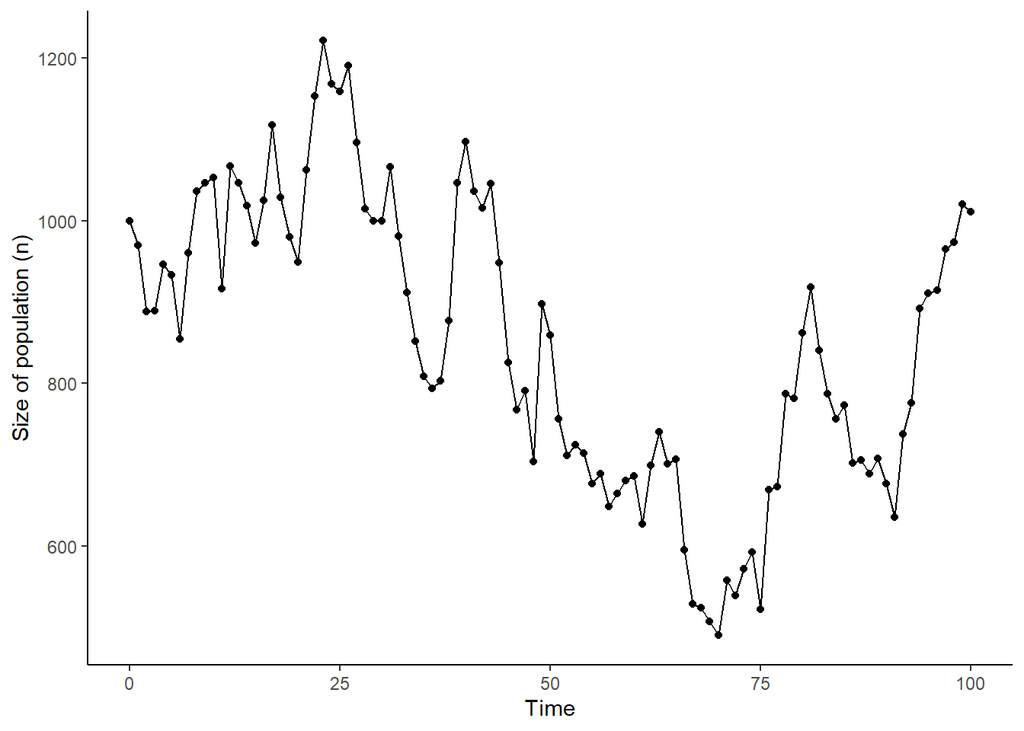

```r
start = 1000
pop = tibble(time = 0:100, n = NA)
pop$n[pop$time == 0] = start

for (t in 1:100){
  growth = rnorm(n =1, mean = 300, sd = 50)
  death = rnorm(n = 1, mean = 300, sd = 50)
  pop$n[pop$time == t] = growth - death + pop$n[pop$time == (t-1)]
}

ggplot(pop, aes(x = time, y = n))+
  geom_point()+
  geom_line()+
  theme_classic()+
  labs(x = 'Time', y = 'Size of population (n)')
```

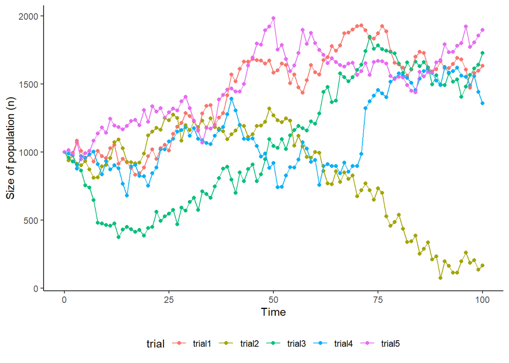

```r
for (i in 1:5){
  trial = paste0('trial',i)
  start = 1000
  pop = tibble(time = 0:100, n = NA, trial = trial)
  pop$n[pop$time == 0] = start

  for (t in 1:100){
  growth = rnorm(n =1, mean = 300, sd = 50)
  death = rnorm(n = 1, mean = 300, sd = 50)
  pop$n[pop$time == t] = growth - death + pop$n[pop$time == (t-1)]
  }

  if (i ==1){
    tpop = pop
  }else{
    tpop = bind_rows(tpop,pop)
  }
}

ggplot(tpop, aes(x = time, y = n, color = trial))+
  geom_point()+
  geom_line()+
  theme_classic()+
  labs(x = 'Time', y = 'Size of population (n)')+
  theme(legend.position = 'bottom')
```

## Homework

### R Homework – 1: Loops and density-independent and -dependent growth models

Please, using RStudio and R, answer the questions below. You can use the class notes, the recommended books, and other web materials to help you answer the questions. You can work on the homework in groups, but please independently send the R code and the answers to the short-essay questions.

**In three weeks (10/19/2021)**, please submit your R code (.R file) and short answers (.docx file) to CANVAS using the following filename structure LastName_HW1_Filetype_Date (e.g., Santos_HW1_R_20210928). Again, you can share and work together on the code, but independently, in your own words, submit your answers to the short essay questions.

For this homework, you will use a dataset that I will attach in the R workshop module in CANVAS. This dataset comprises the catch-per-unit effort (CPUE; a proxy of relative abundance) across three decades for three recreational fish species targeted in the Everglades National Park (catch.csv). Use the function read.csv file to import the catch.csv as data frame in RStudio.

#### Question 1

1. Using R, calculate lambda from one year to the next (i.e., for each time step) for the three fish species using the CPUE as a proxy of abundance.
2. Convert lambda (λ, finite rate of increase) to r (instantaneous rate of increse)
3. Convert r to a monthly rate and back-transformed it to lambda. Append the new values as separated columns in the catch data frame.

#### Question 2

1. Calculate mean(λ) and sd(λ) for the three species using your calculation from Question 1. Try to use either a for-loop or functions in `plyr`, `dplyr` and `purr` to calculate mean(λ) and sd(λ).
2. Using ggplot, plot the mean(λ) and sd(λ) for the three species. Hint: `geom_point()`, `geom_errorbar()` or `geom_pointrange()`.
3. Short essay question 2.1: Based on the mean(λ) and sd(λ) for the three species, what can you tell me about the population growth and fluctuations that these species experienced? Based on the mean(λ), what will be the expected growth into the future? Why?

#### Question 3

1. Calculate the mean, median, and the 25 and 95 percent quantiles of the species CPUE
2. Using a discrete density-dependent growth model, project the population growth for the three species to 50 years based on three carrying capacity values (K: mean(CPUE), median(CPUE), 95-quantile(CPUE)). Use the mean(λ), the mean(CPUE), median(CPUE) and 95-quantile(CPUE) as your K values to project the population growth. Hint: 1 – rd = λ; See Gotelli pages 35-37 and pages Stevens 62-68
3. Using ggplot, plot the population projections for each species. Hint: `facet_wrap()` or `facet_grid()`